#Week 4: Clustering and classification

**Exercise 2**  
Here’s the Boston dataset, which contains data of 506 Boston suburbs. There are 14 variables describing housing values, i.e. some socio-economical and geographical features of the Bostonian suburbs. Declaration of all 14 variables can be found [here](https://stat.ethz.ch/R-manual/R-devel/library/MASS/html/Boston.html).

```r
library(MASS)
library(dplyr)
data("Boston")
glimpse(Boston)
```

```
## Rows: 506
## Columns: 14
## $ crim    <dbl> 0.00632, 0.02731, 0.02729, 0.03237, 0.06905, 0.02985, 0.08829,~
## $ zn      <dbl> 18.0, 0.0, 0.0, 0.0, 0.0, 0.0, 12.5, 12.5, 12.5, 12.5, 12.5, 1~
## $ indus   <dbl> 2.31, 7.07, 7.07, 2.18, 2.18, 2.18, 7.87, 7.87, 7.87, 7.87, 7.~
## $ chas    <int> 0, 0, 0, 0, 0, 0, 0, 0, 0, 0, 0, 0, 0, 0, 0, 0, 0, 0, 0, 0, 0,~
## $ nox     <dbl> 0.538, 0.469, 0.469, 0.458, 0.458, 0.458, 0.524, 0.524, 0.524,~
## $ rm      <dbl> 6.575, 6.421, 7.185, 6.998, 7.147, 6.430, 6.012, 6.172, 5.631,~
## $ age     <dbl> 65.2, 78.9, 61.1, 45.8, 54.2, 58.7, 66.6, 96.1, 100.0, 85.9, 9~
## $ dis     <dbl> 4.0900, 4.9671, 4.9671, 6.0622, 6.0622, 6.0622, 5.5605, 5.9505~
## $ rad     <int> 1, 2, 2, 3, 3, 3, 5, 5, 5, 5, 5, 5, 5, 4, 4, 4, 4, 4, 4, 4, 4,~
## $ tax     <dbl> 296, 242, 242, 222, 222, 222, 311, 311, 311, 311, 311, 311, 31~
## $ ptratio <dbl> 15.3, 17.8, 17.8, 18.7, 18.7, 18.7, 15.2, 15.2, 15.2, 15.2, 15~
## $ black   <dbl> 396.90, 396.90, 392.83, 394.63, 396.90, 394.12, 395.60, 396.90~
## $ lstat   <dbl> 4.98, 9.14, 4.03, 2.94, 5.33, 5.21, 12.43, 19.15, 29.93, 17.10~
## $ medv    <dbl> 24.0, 21.6, 34.7, 33.4, 36.2, 28.7, 22.9, 27.1, 16.5, 18.9, 15~
```

```r
dim(Boston)
```

```
## [1] 506  14
```

**Exercise 3**  
Since the pairs-function provided a massive plot with tiny, non-interpretable scatter plots, I decided to compute a correlation matrix instead. After that, I noticed that computing a correlation matrix and visualizing that were also instructed in DataCamp! Great! So, here comes a visualization in which larger dots with more intensive colors indicate a stronger relationship between two variables in the Boston dataset (red = negative correlation, blue = positive correlation). I also printed out the summary statistics of each variable.

As can be seen in the summary statistics, there seems to be a lot of variation within the variables. Based on the visualized correlation matrix, rad and tax have the strongest positive correlation. There is a strong negative correlation are between lstat [lower status of the population] and medv [owner-occupied homes]. Additionally, dis [distance to employment centres] has a strong negative relationship with indus [proportion of non-retail business acres], nox [air pollution], and age [proportion of old buildings]. Chas [does the tract bound the Charles River], on the contrary, is rather unrelated to any of the other variables.

```r
library(corrplot)
#compute a correlation matrix
cor_matrix <- cor(Boston)%>%
  round(digits = 2)

# print the correlation matrix
cor_matrix
```

```
##          crim    zn indus  chas   nox    rm   age   dis   rad   tax ptratio
## crim     1.00 -0.20  0.41 -0.06  0.42 -0.22  0.35 -0.38  0.63  0.58    0.29
## zn      -0.20  1.00 -0.53 -0.04 -0.52  0.31 -0.57  0.66 -0.31 -0.31   -0.39
## indus    0.41 -0.53  1.00  0.06  0.76 -0.39  0.64 -0.71  0.60  0.72    0.38
## chas    -0.06 -0.04  0.06  1.00  0.09  0.09  0.09 -0.10 -0.01 -0.04   -0.12
## nox      0.42 -0.52  0.76  0.09  1.00 -0.30  0.73 -0.77  0.61  0.67    0.19
## rm      -0.22  0.31 -0.39  0.09 -0.30  1.00 -0.24  0.21 -0.21 -0.29   -0.36
## age      0.35 -0.57  0.64  0.09  0.73 -0.24  1.00 -0.75  0.46  0.51    0.26
## dis     -0.38  0.66 -0.71 -0.10 -0.77  0.21 -0.75  1.00 -0.49 -0.53   -0.23
## rad      0.63 -0.31  0.60 -0.01  0.61 -0.21  0.46 -0.49  1.00  0.91    0.46
## tax      0.58 -0.31  0.72 -0.04  0.67 -0.29  0.51 -0.53  0.91  1.00    0.46
## ptratio  0.29 -0.39  0.38 -0.12  0.19 -0.36  0.26 -0.23  0.46  0.46    1.00
## black   -0.39  0.18 -0.36  0.05 -0.38  0.13 -0.27  0.29 -0.44 -0.44   -0.18
## lstat    0.46 -0.41  0.60 -0.05  0.59 -0.61  0.60 -0.50  0.49  0.54    0.37
## medv    -0.39  0.36 -0.48  0.18 -0.43  0.70 -0.38  0.25 -0.38 -0.47   -0.51
##         black lstat  medv
## crim    -0.39  0.46 -0.39
## zn       0.18 -0.41  0.36
## indus   -0.36  0.60 -0.48
## chas     0.05 -0.05  0.18
## nox     -0.38  0.59 -0.43
## rm       0.13 -0.61  0.70
## age     -0.27  0.60 -0.38
## dis      0.29 -0.50  0.25
## rad     -0.44  0.49 -0.38
## tax     -0.44  0.54 -0.47
## ptratio -0.18  0.37 -0.51
## black    1.00 -0.37  0.33
## lstat   -0.37  1.00 -0.74
## medv     0.33 -0.74  1.00
```

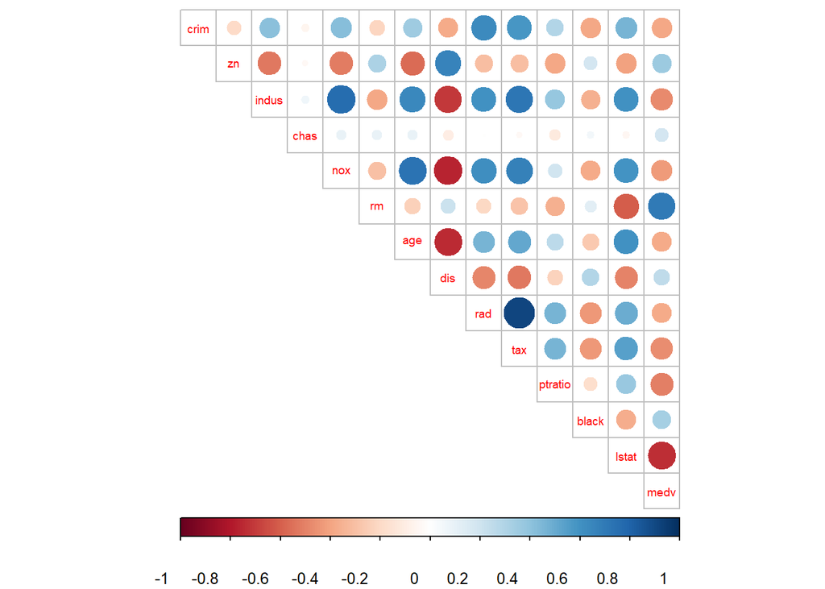

```r
# visualize the correlation matrix
corrplot(cor_matrix, method="circle", type="upper", cl.pos="b", tl.pos="d", tl.cex = 0.6)
```

```r
#compute summary statistics
summary(Boston)
```

```
##       crim                zn             indus            chas
##  Min.   : 0.00632   Min.   :  0.00   Min.   : 0.46   Min.   :0.00000
##  1st Qu.: 0.08205   1st Qu.:  0.00   1st Qu.: 5.19   1st Qu.:0.00000
##  Median : 0.25651   Median :  0.00   Median : 9.69   Median :0.00000
##  Mean   : 3.61352   Mean   : 11.36   Mean   :11.14   Mean   :0.06917
##  3rd Qu.: 3.67708   3rd Qu.: 12.50   3rd Qu.:18.10   3rd Qu.:0.00000
##  Max.   :88.97620   Max.   :100.00   Max.   :27.74   Max.   :1.00000
##       nox               rm             age              dis
##  Min.   :0.3850   Min.   :3.561   Min.   :  2.90   Min.   : 1.130
##  1st Qu.:0.4490   1st Qu.:5.886   1st Qu.: 45.02   1st Qu.: 2.100
##  Median :0.5380   Median :6.208   Median : 77.50   Median : 3.207
##  Mean   :0.5547   Mean   :6.285   Mean   : 68.57   Mean   : 3.795
##  3rd Qu.:0.6240   3rd Qu.:6.623   3rd Qu.: 94.08   3rd Qu.: 5.188
##  Max.   :0.8710   Max.   :8.780   Max.   :100.00   Max.   :12.127
##       rad              tax           ptratio          black
##  Min.   : 1.000   Min.   :187.0   Min.   :12.60   Min.   :  0.32
##  1st Qu.: 4.000   1st Qu.:279.0   1st Qu.:17.40   1st Qu.:375.38
##  Median : 5.000   Median :330.0   Median :19.05   Median :391.44
##  Mean   : 9.549   Mean   :408.2   Mean   :18.46   Mean   :356.67
##  3rd Qu.:24.000   3rd Qu.:666.0   3rd Qu.:20.20   3rd Qu.:396.23
##  Max.   :24.000   Max.   :711.0   Max.   :22.00   Max.   :396.90
##      lstat            medv
##  Min.   : 1.73   Min.   : 5.00
##  1st Qu.: 6.95   1st Qu.:17.02
##  Median :11.36   Median :21.20
##  Mean   :12.65   Mean   :22.53
##  3rd Qu.:16.95   3rd Qu.:25.00
##  Max.   :37.97   Max.   :50.00
```

**Exercise 4**  
Here I standardize the whole dataset. As we see in the summary statistics of the variables, the means are set to zero.

```r
boston_scaled <- scale(Boston) #standardize the dataset
summary(boston_scaled)
```

```
##       crim                 zn               indus              chas
##  Min.   :-0.419367   Min.   :-0.48724   Min.   :-1.5563   Min.   :-0.2723
##  1st Qu.:-0.410563   1st Qu.:-0.48724   1st Qu.:-0.8668   1st Qu.:-0.2723
##  Median :-0.390280   Median :-0.48724   Median :-0.2109   Median :-0.2723
##  Mean   : 0.000000   Mean   : 0.00000   Mean   : 0.0000   Mean   : 0.0000
##  3rd Qu.: 0.007389   3rd Qu.: 0.04872   3rd Qu.: 1.0150   3rd Qu.:-0.2723
##  Max.   : 9.924110   Max.   : 3.80047   Max.   : 2.4202   Max.   : 3.6648
##       nox                rm               age               dis
##  Min.   :-1.4644   Min.   :-3.8764   Min.   :-2.3331   Min.   :-1.2658
##  1st Qu.:-0.9121   1st Qu.:-0.5681   1st Qu.:-0.8366   1st Qu.:-0.8049
##  Median :-0.1441   Median :-0.1084   Median : 0.3171   Median :-0.2790
##  Mean   : 0.0000   Mean   : 0.0000   Mean   : 0.0000   Mean   : 0.0000
##  3rd Qu.: 0.5981   3rd Qu.: 0.4823   3rd Qu.: 0.9059   3rd Qu.: 0.6617
##  Max.   : 2.7296   Max.   : 3.5515   Max.   : 1.1164   Max.   : 3.9566
##       rad               tax             ptratio            black
##  Min.   :-0.9819   Min.   :-1.3127   Min.   :-2.7047   Min.   :-3.9033
##  1st Qu.:-0.6373   1st Qu.:-0.7668   1st Qu.:-0.4876   1st Qu.: 0.2049
##  Median :-0.5225   Median :-0.4642   Median : 0.2746   Median : 0.3808
##  Mean   : 0.0000   Mean   : 0.0000   Mean   : 0.0000   Mean   : 0.0000
##  3rd Qu.: 1.6596   3rd Qu.: 1.5294   3rd Qu.: 0.8058   3rd Qu.: 0.4332
##  Max.   : 1.6596   Max.   : 1.7964   Max.   : 1.6372   Max.   : 0.4406
##      lstat              medv
##  Min.   :-1.5296   Min.   :-1.9063
##  1st Qu.:-0.7986   1st Qu.:-0.5989
##  Median :-0.1811   Median :-0.1449
##  Mean   : 0.0000   Mean   : 0.0000
##  3rd Qu.: 0.6024   3rd Qu.: 0.2683
##  Max.   : 3.5453   Max.   : 2.9865
```

```r
boston_scaled <- as.data.frame(boston_scaled) #change the type
```

Then, I create a categorical variable of the crime rate in the Boston dataset, with low, medium low, medium high, and high categories included and replace the old crime rate variable with this one.

```r
# create a quantile vector of crim and print it
bins <- quantile(boston_scaled$crim)
bins
```

```
##           0%          25%          50%          75%         100%
## -0.419366929 -0.410563278 -0.390280295  0.007389247  9.924109610
```

```r
# create a categorical variable 'crime'
crime <- cut(boston_scaled$crim, breaks = bins, include.lowest = TRUE, label = c("low", "med_low", "med_high", "high"))

# look at the table of the new factor crime
table(crime)
```

```
## crime
##      low  med_low med_high     high
##      127      126      126      127
```

```r
# remove original crim from the dataset
boston_scaled <- dplyr::select(boston_scaled, -crim)

# add the new categorical value to scaled data
boston_scaled <- data.frame(boston_scaled, crime)
```

Last, I divide the dataset to train and test sets.

```r
# number of rows in the Boston dataset
n <- nrow(boston_scaled)

# choose randomly 80% of the rows
ind <- sample(n,  size = n * 0.8)

# create train set
train <- boston_scaled[ind,]

# create test set
test <- boston_scaled[-ind,]
```

**Exercise 5**  
Next, I fit a linear discriminant analysis on the train. In the model, categorical crime rate is predicted by all the other variables in the dataset.

```r
# linear discriminant analysis
lda.fit <- lda(crime ~ ., data = train)
lda.fit
```

```
## Call:
## lda(crime ~ ., data = train)
##
## Prior probabilities of groups:
##       low   med_low  med_high      high
## 0.2450495 0.2475248 0.2574257 0.2500000
##
## Group means:
##                   zn      indus         chas        nox         rm        age
## low       0.84844758 -0.9138162 -0.113254311 -0.8515607  0.4590801 -0.8472687
## med_low  -0.08783966 -0.2732336  0.003267949 -0.5677199 -0.1708105 -0.3085347
## med_high -0.39488943  0.1701177  0.219808462  0.3784423  0.1508238  0.3854884
## high     -0.48724019  1.0171306 -0.116404306  1.0343614 -0.4813978  0.8301815
##                 dis        rad        tax     ptratio      black       lstat
## low       0.8471289 -0.7034549 -0.7756274 -0.41943727  0.3740594 -0.75878324
## med_low   0.3542588 -0.5477507 -0.4729353 -0.01918459  0.3063937 -0.09519078
## med_high -0.3542868 -0.3965947 -0.2948257 -0.24638875  0.1084125 -0.05309028
## high     -0.8633489  1.6379981  1.5139626  0.78062517 -0.8435074  0.88480150
##                 medv
## low       0.54886861
## med_low  -0.04521057
## med_high  0.21316089
## high     -0.66864939
##
## Coefficients of linear discriminants:
##                  LD1         LD2         LD3
## zn       0.091802702  0.62248003 -0.82654108
## indus    0.003382492 -0.16679283  0.49364988
## chas    -0.085160827 -0.11034447  0.11514112
## nox      0.299325025 -0.93557942 -1.38875699
## rm      -0.148222881 -0.14768226 -0.22893861
## age      0.252389627 -0.30432243  0.01088563
## dis     -0.083388720 -0.27752175  0.16358729
## rad      3.163434894  0.89513772 -0.11224329
## tax      0.043121762  0.01875735  0.37609405
## ptratio  0.100437772 -0.08306029 -0.28644242
## black   -0.148835428  0.01568906  0.10677620
## lstat    0.190356956 -0.11063861  0.39505887
## medv     0.181211600 -0.32771843 -0.21420200
##
## Proportion of trace:
##    LD1    LD2    LD3
## 0.9529 0.0334 0.0136
```

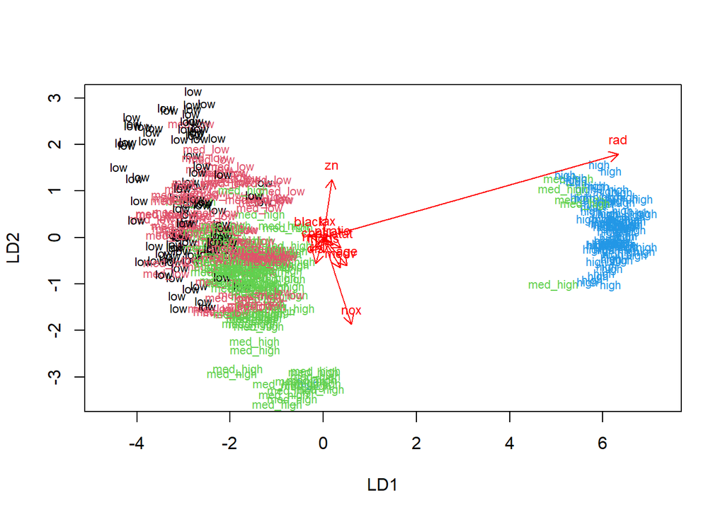

```
## integer(0)
```

```r
# the function for lda biplot arrows
lda.arrows <- function(x, myscale = 1, arrow_heads = 0.1, color = "red", tex = 0.75, choices = c(1,2)){
  heads <- coef(x)
  arrows(x0 = 0, y0 = 0,
         x1 = myscale * heads[,choices[1]],
         y1 = myscale * heads[,choices[2]], col=color, length = arrow_heads)
  text(myscale * heads[,choices], labels = row.names(heads),
       cex = tex, col=color, pos=3)
}

# target classes as numeric
classes <- as.numeric(train$crime)

# plot the lda results
plot(lda.fit, dimen = 2, col = classes, pch = classes) + lda.arrows(lda.fit, myscale = 2)
```

**Exercise 6**  
First, I save the crime classes from the test dataset and then modify the dataset by removing the classes. This is done to see how the LDA model performs in predicting the classes. The cross tabulation clearly shows that the classifier does good job in predicting crime rates: it mostly predicts the correct classes and most of the incorrect predictions are neighboring classes.

```r
# save the correct classes from test data
correct_classes <- test$crime

# remove the crime variable from test data
test <- select(test, -crime)

# predict classes with test data
lda.pred <- predict(lda.fit, newdata = test)

# cross tabulate the results
table(correct = correct_classes, predicted = lda.pred$class)
```

```
##           predicted
## correct    low med_low med_high high
##   low       22       5        1    0
##   med_low    4      18        4    0
##   med_high   0       7       14    1
##   high       0       0        0   26
```

```r
#reload and standardize the Boston dataset
boston2 <- Boston
scaled2 <- scale(boston2)
scaled2 <- as.data.frame(boston2)

dist_eu <- dist(boston2) #euclidean distances
```

First, I run a k-means clustering with a random number of centroids (3). Then I determine the optimal number of clusters using the total WCSS (within cluster sum of squares). In this case, the optimal number is two (see the first figure below). Last, I run the cluster analysis again with the optimal number of clusters determined. Scatter plots of the variables with the two clusters in black and red can be seen below.

It seems that most of the variables are somehow related to the clusters. For example, tax [full-value property-tax rate], ptratio [pupil-teacher ratio], rad [accessibility to radial highways], age [proportion of old buildings], and nox [air pollution] seem highly related to suburb cluster membership. Suburbs high in tax and with a certain, rather high ptratio belong to the red cluster regardless of the values of their neighboring variables. Suburbs with a greater age and an increased nox also tend to belong to the red cluster. Chas [does the tract bound the Charles River], in turn, was unrelated to the other variables in terms of correlation (see Exercise 3) and seems also unrelated to the clustering of the suburbs.

Altogether, one interpretation could be that the red cluster comprises of suburbs where most people live: not the downtowns, peripheral areas, or industrial estates with only few inhabitants, but the suburbs where most buildings are dwelling houses.

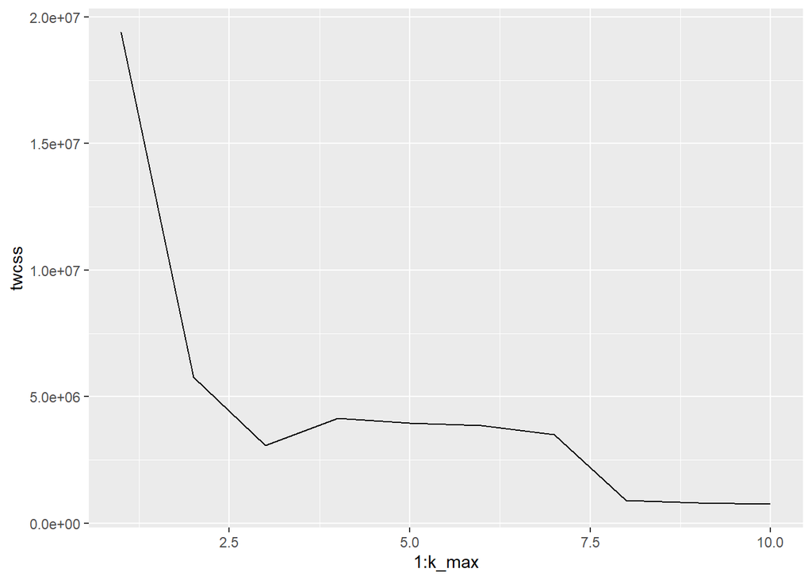

```r
# first k-means clustering with a random number of clusters
km <- kmeans(scaled2, centers = 3)

# set seed so that the results won't change
set.seed(123)

# determine the number of clusters
k_max <- 10

# calculate the total within sum of squares
twcss <- sapply(1:k_max, function(k){kmeans(scaled2, k)$tot.withinss})

# visualize the results
library(ggplot2)
qplot(x = 1:k_max, y = twcss, geom = 'line')
```

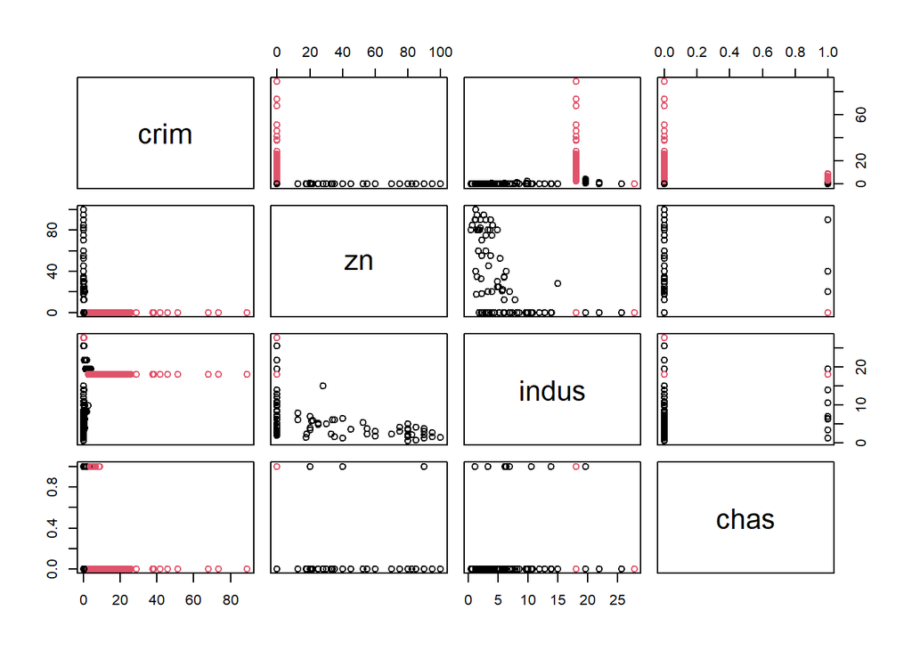

```r
# k-means clustering
km <- kmeans(scaled2, centers = 2)

# plot the Boston dataset with clusters
pairs(scaled2[1:4], col = km$cluster)
```

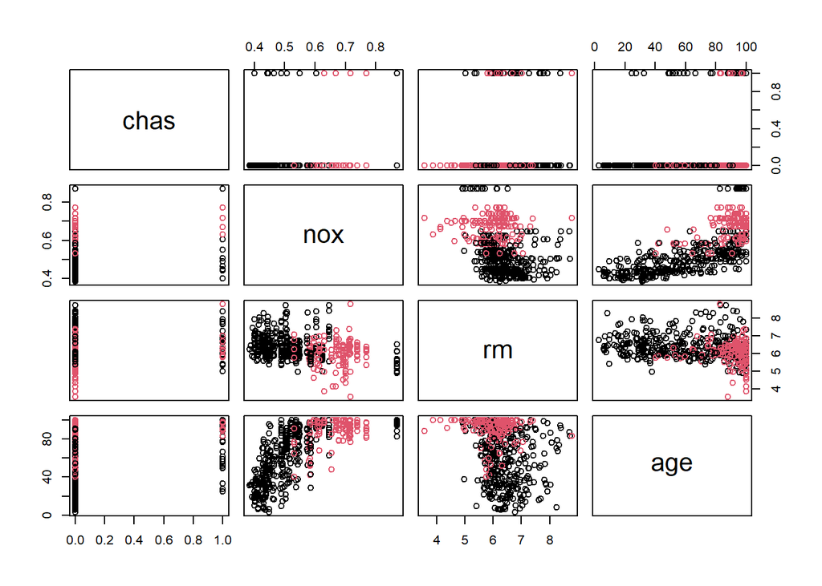

```r
pairs(scaled2[4:7], col = km$cluster)
```

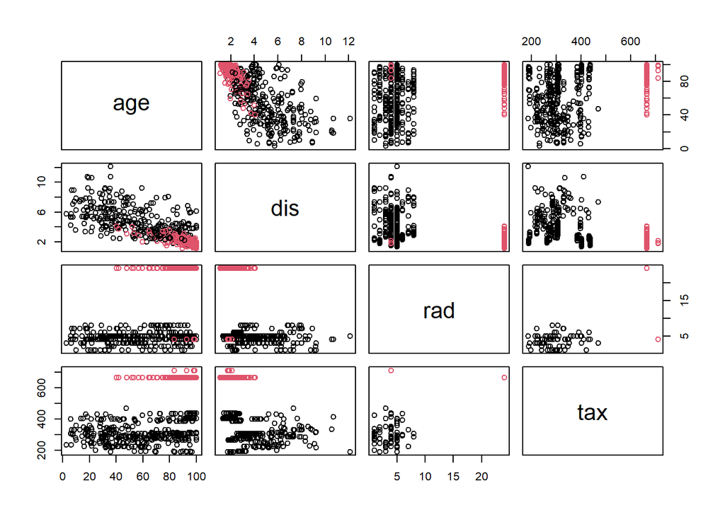

```r
pairs(scaled2[7:10], col = km$cluster)
```

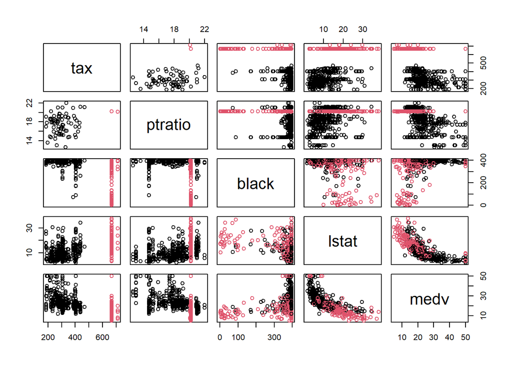

```r
pairs(scaled2[10:14], col = km$cluster)
```